# R Notebook

```r
library(tidyverse)
```

```r
cancer_data_all_scotland <- read_csv("data/raw_data/cancer_data_all_Scot.csv") %>%
  janitor::clean_names()
cancer_data_by_HB <- read_csv("data/raw_data/cancer_data_by_HB.csv") %>%
  janitor::clean_names()
HB_lookup_tibble <- read_csv("data/raw_data/geo_HB_labels_lookup.csv") %>%
  janitor::clean_names()
```

```r
borders_hb_code <- HB_lookup_tibble %>%
  filter(hb_name == "NHS Borders") %>%
  select(hb) %>%
  pull()
```

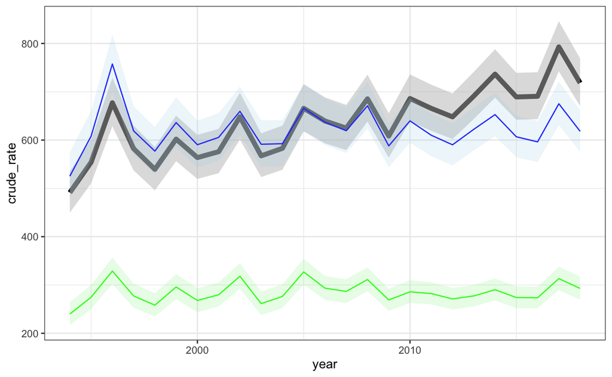

```r
cancer_data_by_HB %>%
  filter(hb == borders_hb_code) %>%
  filter(cancer_site == "All cancer types") %>%
  filter(sex == "All") %>%
  ggplot() +
  aes(x = year) +
  geom_line(
    aes(y = crude_rate), size = 2
  ) +
  geom_ribbon(
    aes(ymin = crude_rate_lower95pc_confidence_interval,
        ymax = crude_rate_upper95pc_confidence_interval), fill = "grey", alpha = 0.5
  ) +
    geom_line(
    aes(y = easr), colour = "blue"
  ) +
  geom_ribbon(
    aes(ymin = easr_lower95pc_confidence_interval,
        ymax = easr_upper95pc_confidence_interval), fill = "light blue", alpha = 0.2
  ) +
    geom_line(
    aes(y = wasr), colour = "green"
  ) +
  geom_ribbon(
    aes(ymin = wasr_lower95pc_confidence_interval,
        ymax = wasr_upper95pc_confidence_interval), fill = "light green", alpha = 0.2
  ) +
  theme_bw()
```

```r
cancer_data_long <- cancer_data_by_HB %>%
  select(-cancer_site_icd10code) %>%
  mutate(group = row_number()) %>%
  rename(sir = standardised_incidence_ratio) %>%
  pivot_longer(cols = -c(hb:incidences_all_ages,
                       easr_lower95pc_confidence_interval_qf,
                       easr_upper95pc_confidence_interval_qf,
                       wasr_lower95pc_confidence_interval_qf,
                       wasr_upper95pc_confidence_interval_qf,
                       group),
               names_pattern = "([^_]*)([_a-z0-9$]*)",
               names_to = c("measurement", "limit")) %>%
  mutate(limit = recode(limit, "_rate" = "")) %>%
  mutate(limit = case_when(
    str_detect(limit, "lower") ~ "lower_95pc_c_i",
    str_detect(limit, "upper") ~ "upper_95pc_c_i",
    limit == "" ~ "value",
    TRUE ~ limit)
  ) %>%
  pivot_wider(id_cols = -c(limit,value), names_from = limit,
              values_from = value, names_repair = "check_unique") %>%
  mutate(measurement = str_to_upper(measurement)) %>%
  filter(incidences_all_ages > 20) %>%
  select(-easr_lower95pc_confidence_interval_qf,
         -easr_upper95pc_confidence_interval_qf,
         -wasr_lower95pc_confidence_interval_qf,
         -wasr_upper95pc_confidence_interval_qf,
         -sex_qf) %>%
  filter(cancer_site == "All cancer types") %>%
  filter(sex == "All") %>%
  filter(hb == "S08000015")
```

| hb | cancer_site | sex | year | incidences_all_ages | group | measurement | value | lower_95pc_c_i | upper_95pc_c_i |
| --- | --- | --- | --- | --- | --- | --- | --- | --- | --- |
| S08000015 | All cancer types | All | 1994 | 1815 | 1 | WASR | 277.5045 | 263.8182 | 291.532 |

[figure not shown]

[figure not shown]

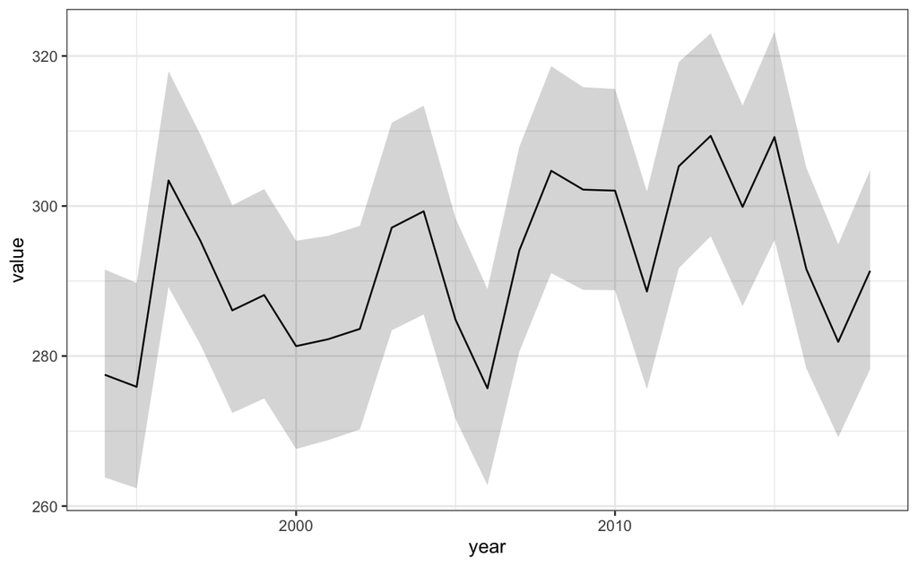

```r
make_line_plot(cancer_data_wasr)
```

[figure not shown]

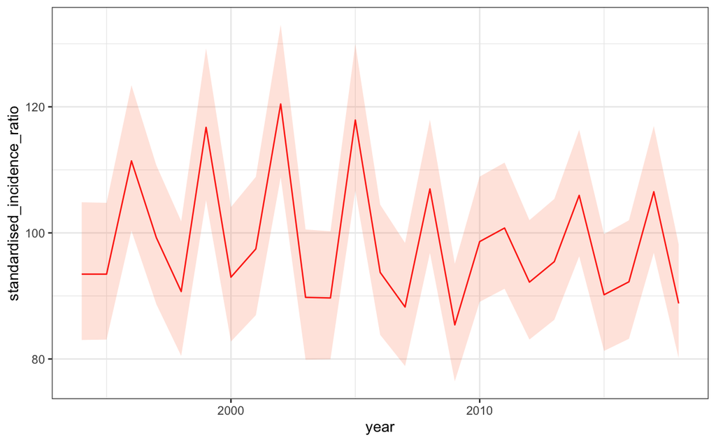

```r
cancer_data_by_HB %>%
  filter(hb == borders_hb_code) %>%
  filter(cancer_site == "All cancer types") %>%
  filter(sex == "Female") %>%
  ggplot() +
  aes(x = year) +
  geom_line(
    aes(y = standardised_incidence_ratio), colour = "red"
  ) +
  geom_ribbon(
    aes(ymin = sir_lower95pc_confidence_interval,
        ymax = sir_upper95pc_confidence_interval), fill = "coral", alpha = 0.2
  ) +
  theme_bw()
```

```r
hb_shapes <- readOGR(
  dsn ="../data/shapefiles/SG_NHS_HealthBoards_2019/",
  layer = "SG_NHS_HealthBoards_2019",
  GDAL1_integer64_policy = TRUE)
```

```
Error in ogrInfo(dsn = dsn, layer = layer, encoding = encoding, use_iconv = use_iconv,  :
  Cannot open data source
```

cancer_site = body location of cancer crude_rate = total number of events / population

european age-standardised rate world age-standardised rate

Confidence intervals for age-standardised rates (EASR and WASR) have been calculated using a formula which works only when numbers are sufficiently large. They are therefore set to ‘not applicable’ in the event of there being fewer than 20 cases.

In comparing cancer incidence between areas or over time, three important factors must be considered—the number of people at risk, their sex and their age.

Since the risk of developing cancer doubles with every eight or nine years of life, an area with an older population would be expected, all else being equal, to have more incident cancer cases than an area with a younger population. There are several different approaches available to adjust for differences in age; this atlas has used indirect standardization, which is the most appropriate method for small area comparisons, as it provides more stable rates than other standardization techniques, and works even if there is no population-at-risk in some age groups within the area (Estève et al., 1994).

A Standardized Incidence Ratio (SIR) is used to determine if the occurrence of cancer in a relatively small population is high or low. An SIR analysis can tell us if the number of observed cancer cases in a particular geographic area is higher or lower than expected, given the population and age distribution for that community.

The SIR is obtained by dividing the observed number of cases of cancer by the “expected” number of cases. The expected number is the number of cases that would occur in a community if the disease rate in a larger reference population (usually the state or country) occurred in that community. Since cancer rates increase strongly with age, the SIR takes into account whether a community’s population is older or younger than the reference population.